# **Econometrics**

Heteroskedasticity: Bank Wages

Sujiao (Emma) ZHAO

2021/10/27 (updated: 2021-11-10)

We consider the bank wage data of 474 bank employees. It will be discussed: three jobs categories, a possible model for heteroskedasticity and visual impression of the amount of variation in wages.

The bank employees can be divided according to three job categories: administrative jobs, custodial jobs and management jobs. It may well be that the amount the variation in wages differs among these three categories. For example, two managers with the same level of education may have quite different wages because they have different management experience or their jobs responsibilities differ. However, for a given level of education, it may be expected that employees with custodial jobs earn similar wages.

Let us consider the following regression model

$$\begin{equation*}
logsalary_i= \beta_1 + \beta_2 educ_i + \beta_3 gender_i + \beta_4 minority_i + \beta_5 dumjcat2_i + \beta_6 dumjcat3_i+u_i,
\end{equation*}$$

where $logsalary$ is the logarithm of yearly wage, $educ$ is the number of years of education, $gender$ is a gender dummy (1 for males, 0 for females), and $minority$ is a minority dummy (1 for minorities, 0 otherwise). The administration is taken as the reference category, and $dumjcat2$ and $dumjcat3$ are dummy variables ($dumjcat2=1$ for individuals with a custodial job and $dumjcat2=0$ otherwise, and $dumjcat3=1$ for individuals with a management job and $dumjcat3=0$ otherwise).

First, we need to read the bank_wages dataset. We assume that we have changed to the folder where the dataset is located. We can now read the file.

```r
library(haven) # import Stata data
bwages <- read_dta("bank_wages.dta")
```

We can do some descriptive statistics:

```r
library(stargazer)
stargazer(as.data.frame(bwages), type = "text")
```

```
##
## ======================================================================
## Statistic    N     Mean     St. Dev.   Min   Pctl(25) Pctl(75)   Max
## ----------------------------------------------------------------------
## idnumber    474  237.500    136.976     1     119.2    355.8     474
## salary      474 34,419.570 17,075.660 15,750  24,000  36,937.5 135,000
## logsalary   474   10.357     0.397    9.665   10.086   10.517  11.813
## educ        474   13.492     2.885      8       12       15      21
## salbegin    474 17,016.090 7,870.638  9,000  12,487.5  17,490  79,980
## logsalbegin 474   9.669      0.353    9.105   9.432    9.769   11.290
## gender      474   0.544      0.499      0       0        1        1
## minority    474   0.219      0.414      0       0        0        1
## jobcat      474   1.411      0.773      1       1        1        3
## ----------------------------------------------------------------------
```

We need to create factor variable *jobcat2*.

```r
bwages$jobcat2 <- factor(bwages$jobcat,
                       levels = c(1,2,3),
                       labels = c("administrative", "custodial", "management"))
```

We now run the regression.

```r
library(stargazer)
reg1<-lm(logsalary~educ+gender+minority+jobcat2, data = bwages)
stargazer(reg1, type="text", digits=8)
```

```
##
## =================================================
##                          Dependent variable:
##                     -----------------------------
##                               logsalary
## -------------------------------------------------
## educ                        0.04419174***
##                             (0.00428498)
##
## gender                      0.17834030***
##                             (0.02096225)
##
## minority                   -0.07485807***
##                             (0.02245877)
##
## jobcat2custodial            0.17035950***
##                             (0.04349361)
##
## jobcat2management           0.53907540***
##                             (0.03021302)
##
## Constant                    9.57469400***
##                             (0.05421791)
##
## -------------------------------------------------
## Observations                     474
## R2                           0.76077460
## Adjusted R2                  0.75821880
## Residual Std. Error     0.19537420 (df = 468)
## F Statistic         297.66280000*** (df = 5; 468)
## =================================================
## Note:                 *p<0.1; **p<0.05; ***p<0.01
```

The following graphs show for each job category both the unconditional variation in $logsalary$ and the conditional variation using the variation of the estimates of the OLS of $logsalary$ and the variation of the OLS residuals of the above regression model.

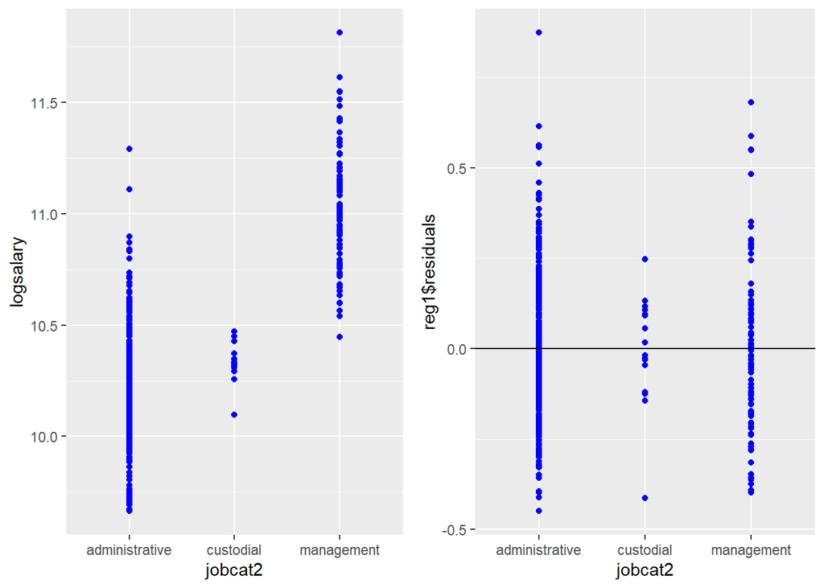

```r
library(ggplot2)
fig1<-ggplot(data = bwages, aes(y = logsalary, x = jobcat2)) + geom_point(col = 'blue') + geom_abline(slope = 0)
fig2<-ggplot(data = bwages, aes(y = reg1$residuals, x = jobcat2)) + geom_point(col = 'blue') + geom_abline(slope = 0)

library(grid)
# Create a new page
grid.newpage()
# Next push the vissible area with a layout of 1 row and 2 columns using pushViewport()
pushViewport(viewport(layout = grid.layout(1,2)))

print(fig1, vp = viewport(layout.pos.row = 1, layout.pos.col = 1))
print(fig2, vp = viewport(layout.pos.row = 1, layout.pos.col = 2))
```

The graphs indicate that the variations are the smallest for custodial jobs.

## Checking homoskedasticity of residuals

One common assumption for the OLS regression is the homogeneity of variance of the residuals. If the model is well-fitted, there should be no pattern to the residuals plotted against the fitted values. If the variance of the residuals is non-constant, then the residual variance is said to be “heteroskedastic.” There are graphical and non-graphical methods for detecting heteroskedasticity. A commonly used graphical method is to plot the residuals versus fitted (predicted) values.

We do this by drawong the residual plot in R (question: why don’t we drawn the scatter Diagram with the regression line?). Note that a reference line at $y=0.$ is inserted by the argument `geom_abline(slope = 0)`. We see that the pattern of the data points is getting a little narrower towards the right end, which is an indication of heteroskedasticity.

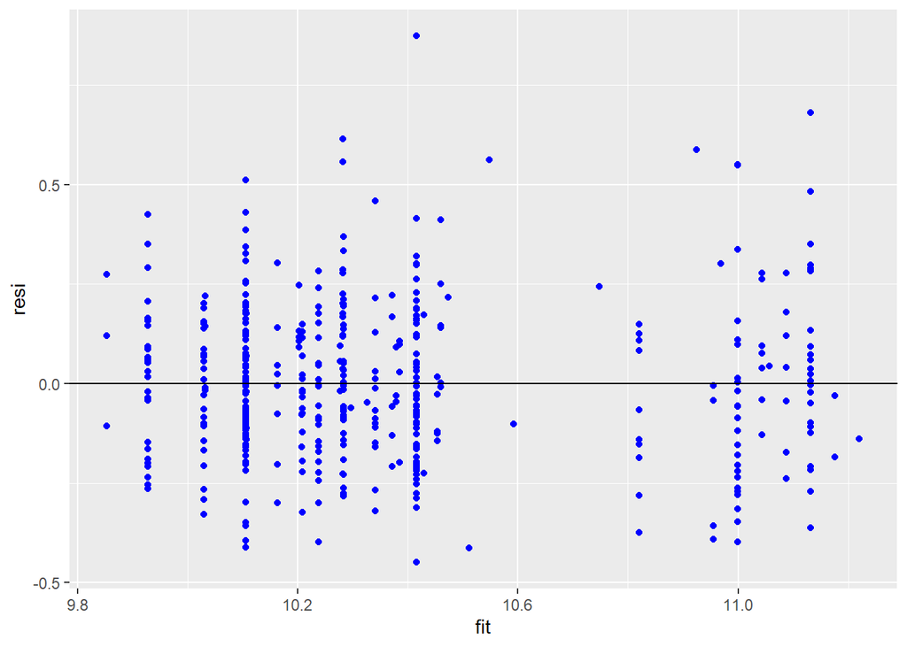

```r
library(ggplot2)
bwages$resi <- reg1$residuals
bwages$fit <- reg1$fitted.values
ggplot(data = bwages, aes(y = resi, x = fit)) + geom_point(col = 'blue') + geom_abline(slope = 0)
```

Below we use the studentized test proposed by R. Koenker in his 1981 article *A Note on Studentizing a Test for Heteroscedasticity*.

**Breusch-Pagan test**

```r
library(lmtest)
bptest(reg1, varformula = ~ educ+gender+minority+jobcat2, data = bwages, studentize = T)
```

```
##
##  studentized Breusch-Pagan test
##
## data:  reg1
## BP = 13.04, df = 5, p-value = 0.023
```

**White test**

```r
library(lmtest)
bptest(reg1, varformula = ~ fit+I(fit^2), data = bwages, studentize = T)
```

```
##
##  studentized Breusch-Pagan test
##
## data:  reg1
## BP = 8.7175, df = 2, p-value = 0.01279
```

## Dealing with heteroskedasticity

$\mbox{ 1. Respecify the model and/or transform the variables}$

Sometimes heteroskedasticity results are from the improper model specification. There may be subgroup differences. Effects of variables may not be linear. Perhaps some important variables have been left out of the model. If these are problems, deal with them first.

$\mbox{2. Use robust standard errors}$

R includes options with most routines for estimating robust standard errors (also referred to as Huber/White estimators or sandwich estimators of variance). As noted above, heteroskedasticity causes standard errors to be biased. When applying OLS it is common to assume that errors are both independent and identically distributed; robust standard errors relax either or both of those assumptions. Hence, when heteroskedasticity is present, robust standard errors tend to be more trustworthy.

In R the `coeftest` from the lmtest package can be used in combination with the function `vcovHC` from the sandwich package to calculate robust standard errors.

Let us rerun the above regression with the `coeftest` option.

```r
library(lmtest)
library(sandwich)
# OLS
stargazer(reg1, type="text", digits=8)
```

```
##
## =================================================
##                          Dependent variable:
##                     -----------------------------
##                               logsalary
## -------------------------------------------------
## educ                        0.04419174***
##                             (0.00428498)
##
## gender                      0.17834030***
##                             (0.02096225)
##
## minority                   -0.07485807***
##                             (0.02245877)
##
## jobcat2custodial            0.17035950***
##                             (0.04349361)
##
## jobcat2management           0.53907540***
##                             (0.03021302)
##
## Constant                    9.57469400***
##                             (0.05421791)
##
## -------------------------------------------------
## Observations                     474
## R2                           0.76077460
## Adjusted R2                  0.75821880
## Residual Std. Error     0.19537420 (df = 468)
## F Statistic         297.66280000*** (df = 5; 468)
## =================================================
## Note:                 *p<0.1; **p<0.05; ***p<0.01
```

```r
# Robust Standard Errors
coeftest(reg1, vcov = vcovHC(reg1, "HC0"))
```

```
##
## t test of coefficients:
##
##                     Estimate Std. Error  t value  Pr(>|t|)
## (Intercept)        9.5746942  0.0541314 176.8786 < 2.2e-16 ***
## educ               0.0441917  0.0043964  10.0517 < 2.2e-16 ***
## gender             0.1783403  0.0198578   8.9809 < 2.2e-16 ***
## minority          -0.0748581  0.0205674  -3.6396 0.0003034 ***
## jobcat2custodial   0.1703595  0.0328155   5.1914 3.117e-07 ***
## jobcat2management  0.5390754  0.0356591  15.1175 < 2.2e-16 ***
## ---
## Signif. codes:  0 '***' 0.001 '**' 0.01 '*' 0.05 '.' 0.1 ' ' 1
```

```r
coeftest(reg1, vcov = vcovHC(reg1, "HC1"))
```

```
##
## t test of coefficients:
##
##                     Estimate Std. Error  t value  Pr(>|t|)
## (Intercept)        9.5746942  0.0544773 175.7556 < 2.2e-16 ***
## educ               0.0441917  0.0044245   9.9879 < 2.2e-16 ***
## gender             0.1783403  0.0199847   8.9239 < 2.2e-16 ***
## minority          -0.0748581  0.0206988  -3.6165  0.000331 ***
## jobcat2custodial   0.1703595  0.0330252   5.1585 3.684e-07 ***
## jobcat2management  0.5390754  0.0358870  15.0215 < 2.2e-16 ***
## ---
## Signif. codes:  0 '***' 0.001 '**' 0.01 '*' 0.05 '.' 0.1 ' ' 1
```

```r
coeftest(reg1, vcov = vcovHC(reg1, "HC2"))
```

```
##
## t test of coefficients:
##
##                     Estimate Std. Error  t value  Pr(>|t|)
## (Intercept)        9.5746942  0.0545868 175.4030 < 2.2e-16 ***
## educ               0.0441917  0.0044336   9.9675 < 2.2e-16 ***
## gender             0.1783403  0.0199739   8.9287 < 2.2e-16 ***
## minority          -0.0748581  0.0207454  -3.6084 0.0003413 ***
## jobcat2custodial   0.1703595  0.0334212   5.0974 5.009e-07 ***
## jobcat2management  0.5390754  0.0359299  15.0035 < 2.2e-16 ***
## ---
## Signif. codes:  0 '***' 0.001 '**' 0.01 '*' 0.05 '.' 0.1 ' ' 1
```

```r
coeftest(reg1, vcov = vcovHC(reg1, "HC3"))
```

```
##
## t test of coefficients:
##
##                     Estimate Std. Error  t value  Pr(>|t|)
## (Intercept)        9.5746942  0.0550492 173.9297 < 2.2e-16 ***
## educ               0.0441917  0.0044713   9.8834 < 2.2e-16 ***
## gender             0.1783403  0.0200911   8.8766 < 2.2e-16 ***
## minority          -0.0748581  0.0209259  -3.5773 0.0003833 ***
## jobcat2custodial   0.1703595  0.0340428   5.0043 7.951e-07 ***
## jobcat2management  0.5390754  0.0362037  14.8901 < 2.2e-16 ***
## ---
## Signif. codes:  0 '***' 0.001 '**' 0.01 '*' 0.05 '.' 0.1 ' ' 1
```

```r
coeftest(reg1, vcov = vcovHC(reg1, "HC4"))
```

```
##
## t test of coefficients:
##
##                     Estimate Std. Error  t value  Pr(>|t|)
## (Intercept)        9.5746942  0.0549858 174.1304 < 2.2e-16 ***
## educ               0.0441917  0.0044657   9.8959 < 2.2e-16 ***
## gender             0.1783403  0.0199981   8.9178 < 2.2e-16 ***
## minority          -0.0748581  0.0208876  -3.5839 0.0003741 ***
## jobcat2custodial   0.1703595  0.0349459   4.8749 1.493e-06 ***
## jobcat2management  0.5390754  0.0360563  14.9509 < 2.2e-16 ***
## ---
## Signif. codes:  0 '***' 0.001 '**' 0.01 '*' 0.05 '.' 0.1 ' ' 1
```

Comparing the results with the earlier regression, we note that none of the coefficient estimates changed, but the standard errors and hence the t values are a little different. Had there been more heteroskedasticity in these data, we would have probably seen bigger changes.

Caution: Do not confuse robust standard errors with robust regression. Despite their similar names, they deal with different problems: Robust standard errors address the problem of errors that are not independent and identically distributed. The use of robust standard errors will not change the coefficient estimates provided by OLS, but they will change the standard errors and significance tests.

Robust regression deals with the problem of outliers in a regression. Robust regression uses a weighting scheme that causes outliers to have less impact on the estimates of regression coefficients.

$\mbox{3. Use Weighted Least Squares or Feasible Weighted Least Squares}$

We concluded that the unexplained variation of the error terms in the logarithmic wages might differ among the three job categories. Let us assume the following multiplicative model for

$$\sigma_i^2= \exp^{\gamma_1 +\gamma_2 dumjcat2_i + \gamma_3 dumjcat3_i}.$$

In this case, we have to use two-step FWLS estimates. First we need to obtain estimates for $\gamma_1$, $\gamma_2$, and $\gamma_3$. Since we do not observe $\sigma_i^2$ we use $e_i^2$ instead. Thus, the regression to estimate is

$$\begin{equation}
log(e_i^2)=\gamma_1 +\gamma_2 dumjcat2_i + \gamma_3 dumjcat3_i+v_i
\end{equation}$$

```r
varfunc.ols <- lm(log(resi^2) ~ jobcat2, data = bwages)
stargazer(varfunc.ols, type="text", digits=8)
```

```
##
## ===============================================
##                         Dependent variable:
##                     ---------------------------
##                             log(resi2)
## -----------------------------------------------
## jobcat2custodial            -0.28920050
##                            (0.46921780)
##
## jobcat2management           0.46048720
##                            (0.28479880)
##
## Constant                  -4.73323400***
##                            (0.12345940)
##
## -----------------------------------------------
## Observations                    474
## R2                          0.00688225
## Adjusted R2                 0.00266519
## Residual Std. Error    2.35221700 (df = 471)
## F Statistic          1.63200200 (df = 2; 471)
## ===============================================
## Note:               *p<0.1; **p<0.05; ***p<0.01
```

With our estimates at hand we can estimate $\sigma_i^2$, then we are ready to estimate our FGLS model

The function `lm()` can do wls estimation if the argument weights is provided under the form of a vector of the same size as the other variables in the model. R takes the square roots of the weights provided to multiply the variables in the regression. Thus, if you wish to multiply the model by $\frac{1}{\sqrt{x_i}}$ , the weights should be $\frac{1}{x_i}$.

```r
bwages$logvarhat=varfunc.ols$fitted.values
bwages$varfunc=exp(bwages$logvarhat)
bwages.gls <- lm(logsalary ~ educ+gender+minority+jobcat2, weights = 1/varfunc, data = bwages)
stargazer(bwages.gls, type="text", digits=8)
```

```
##
## =================================================
##                          Dependent variable:
##                     -----------------------------
##                               logsalary
## -------------------------------------------------
## educ                        0.04269264***
##                             (0.00412252)
##
## gender                      0.17816040***
##                             (0.02034468)
##
## minority                   -0.07836497***
##                             (0.02132956)
##
## jobcat2custodial            0.16728810***
##                             (0.03754156)
##
## jobcat2management           0.54505200***
##                             (0.03288234)
##
## Constant                    9.59490300***
##                             (0.05213093)
##
## -------------------------------------------------
## Observations                     474
## R2                           0.71655770
## Adjusted R2                  0.71352950
## Residual Std. Error     1.98951900 (df = 468)
## F Statistic         236.62600000*** (df = 5; 468)
## =================================================
## Note:                 *p<0.1; **p<0.05; ***p<0.01
```